# Bolivia Pilcomayo Heavy Metals Study - Enhanced Visualization

Katerina Bischel

2025-07-02

# Introduction

This document analyzes heavy metals contamination in the Pilcomayo River basin in Bolivia, using data collected in 2006. The analysis compares contamination levels across water, soil, sediment, vegetation, fish, human, and animal samples against WHO, Codex Alimentarius, CDC, and Bolivian reference standards.

**Key Standards Used:** - WHO Guidelines for Drinking-water Quality (2017) - Codex Alimentarius Standard 193-1995 Rev. 2018  
- CDC Lead Reference Value (2021)

# Water Quality Analysis

```r
# Load water data
water <- read_csv("data/ITA_water_2006.csv")
```

## Lead Contamination in Water Sources

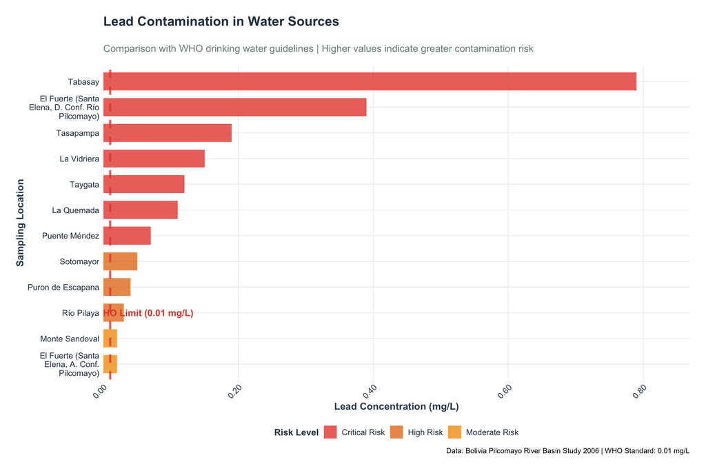

```r
# WHO standard for lead in drinking water
who_lead_limit <- 0.01

water_lead_plot <- water %>%
  mutate(
    Location = str_wrap(Location, 20),
    exceeds_limit = `Pb (mg/l)` > who_lead_limit,
    risk_level = case_when(
      `Pb (mg/l)` <= who_lead_limit ~ "Safe",
      `Pb (mg/l)` <= who_lead_limit * 2 ~ "Moderate Risk",
      `Pb (mg/l)` <= who_lead_limit * 5 ~ "High Risk",
      TRUE ~ "Critical Risk"
    )
  ) %>%
  ggplot(aes(x = reorder(Location, `Pb (mg/l)`), y = `Pb (mg/l)`, fill = risk_level)) +
  geom_col(alpha = 0.8, width = 0.7) +
  geom_hline(
    yintercept = who_lead_limit,
    color = colors_danger,
    linetype = "dashed",
    size = 1.2,
    alpha = 0.8
  ) +
  annotate(
    "text",
    x = 3, y = who_lead_limit + 0.05,
    label = "WHO Limit (0.01 mg/L)",
    color = colors_danger,
    size = 4,
    fontface = "bold"
  ) +
  scale_fill_manual(
    values = c("Safe" = colors_safe,
               "Moderate Risk" = colors_warning,
               "High Risk" = "#e67e22",
               "Critical Risk" = colors_danger),
    name = "Risk Level"
  ) +
  scale_y_continuous(
    labels = scales::number_format(accuracy = 0.01),
    expand = expansion(mult = c(0, 0.1))
  ) +
  labs(
    title = "**Lead Contamination in Water Sources**",
    subtitle = "Comparison with WHO drinking water guidelines | Higher values indicate greater contamination risk",
    x = "Sampling Location",
    y = "Lead Concentration (mg/L)",
    caption = "Data: Bolivia Pilcomayo River Basin Study 2006 | WHO Standard: 0.01 mg/L"
  ) +
  theme_enhanced() +
  coord_flip()

water_lead_plot
```

## Mercury Contamination in Water Sources

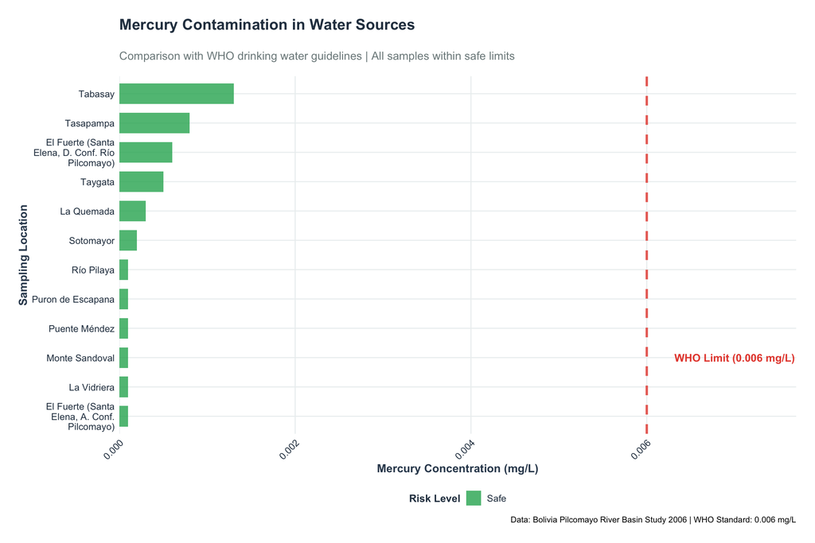

```r
# WHO standard for mercury in drinking water
who_mercury_limit <- 0.006

water_mercury_plot <- water %>%
  mutate(
    Location = str_wrap(Location, 20),
    exceeds_limit = `Hg (mg/l)` > who_mercury_limit,
    risk_level = case_when(
      `Hg (mg/l)` <= who_mercury_limit ~ "Safe",
      `Hg (mg/l)` <= who_mercury_limit * 1.5 ~ "Moderate Risk",
      TRUE ~ "High Risk"
    )
  ) %>%
  ggplot(aes(x = reorder(Location, `Hg (mg/l)`), y = `Hg (mg/l)`, fill = risk_level)) +
  geom_col(alpha = 0.8, width = 0.7) +
  geom_hline(
    yintercept = who_mercury_limit,
    color = colors_danger,
    linetype = "dashed",
    size = 1.2,
    alpha = 0.8
  ) +
  annotate(
    "text",
    x = 3, y = who_mercury_limit + 0.001,
    label = "WHO Limit (0.006 mg/L)",
    color = colors_danger,
    size = 4,
    fontface = "bold"
  ) +
  scale_fill_manual(
    values = c("Safe" = colors_safe,
               "Moderate Risk" = colors_warning,
               "High Risk" = colors_danger),
    name = "Risk Level"
  ) +
  scale_y_continuous(
    labels = scales::number_format(accuracy = 0.001),
    expand = expansion(mult = c(0, 0.1))
  ) +
  labs(
    title = "**Mercury Contamination in Water Sources**",
    subtitle = "Comparison with WHO drinking water guidelines | All samples within safe limits",
    x = "Sampling Location",
    y = "Mercury Concentration (mg/L)",
    caption = "Data: Bolivia Pilcomayo River Basin Study 2006 | WHO Standard: 0.006 mg/L"
  ) +
  theme_enhanced() +
  coord_flip()

water_mercury_plot
```

# Soil and Sediment Analysis

```r
# Load soil and sediment data
soil <- read_csv("data/ITA_soil_2006.csv")
sediment <- read_csv("data/ITA_sed_2006.csv")

# Reference standard for lead in soil
soil_lead_limit <- 70
```